# Part II - 201902-fordgobike-tripdata

## by HAMISI CHAI POJJO

## Investigation Overview

In this investigation I want to check the factors that which affect the duration of trip and also the factors which affect the distance covered during the trip. My main focus was how the variables bike_sharing, gender and user type indipendently affect trip duration and distance covered during the trip.

## Dataset Overview

This data set includes information about individual rides made in a bike-sharing system covering the greater San Francisco Bay area. There are 183412 entries in the tripdata dataset with 16 features. Some of the features include, bike_sharing, user types, genders,trip duration, distance covered among others. After removal of null values and data inconsistencies, the data had 174952 entries.

## Distribution of Trip Distance

Most of the distance data was set to the far left of their axes, suggesting some strong outliers on the right. I had to drop some of the outliers and plot it on a limited scale to show the distribution of the data.After that The graph took a right skewed distribution with majority (over 1000 riders) of the riders covering less than 4Km. The distance covered by most(over 3600) riders was around 1.5 km to 3.5 km.

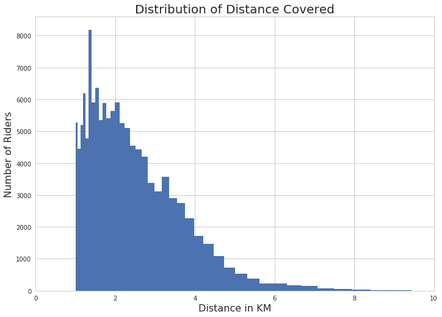

## Distribution of Trip Duration

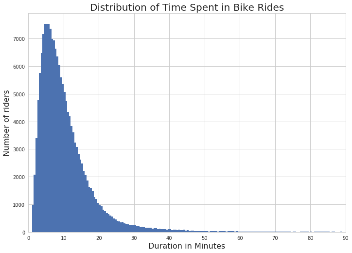

## Distribution of Riders By Type(Subscriber or Customer)

Majority of the bike users are subscribers, taking around a count of 150000 while customners taking the least count with bike users being less than 20000.

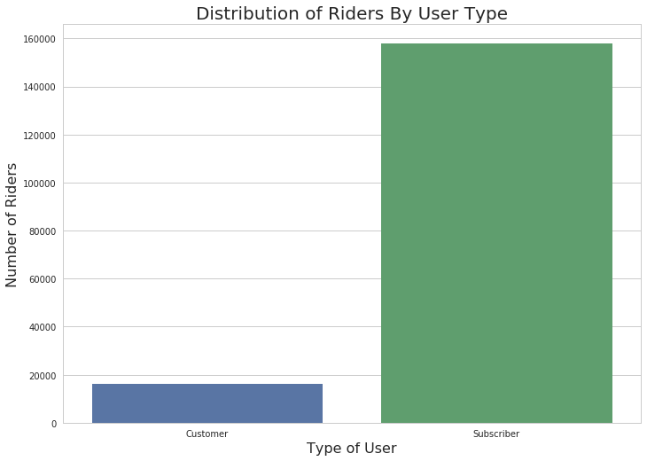

## Distribution of Riders based on Gender

Majority of the members are male, taking 75% of the population, followed by the female who take 23% and those who specified other take 2% of the population.

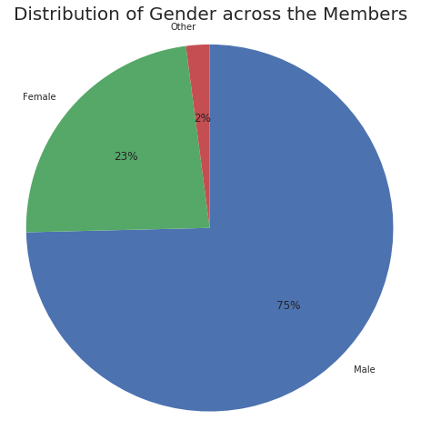

## Bike Sharing vs Distance

From the graph, members who didn't share their bikes during the trip dispalyed a slight positive skew recording a maximum distance of around 4.5KM with a median of around 1.5KM. The members who did share their bike dispalyed a normal distribution recording a maximum of around 3KM and a median of around 1.25KM.

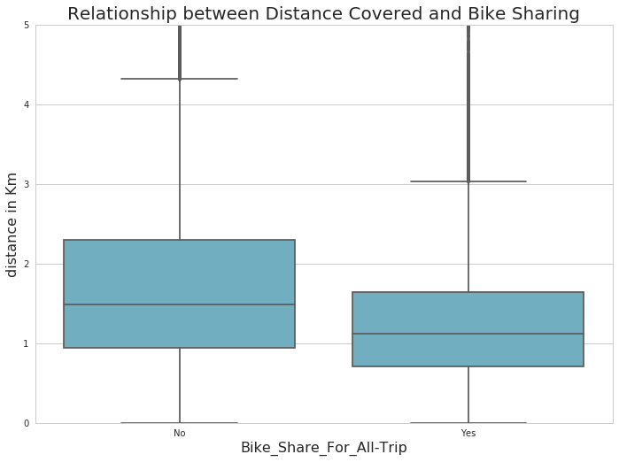

## Bike Sharing vs User Type Vs Distance

From the visualization, the customers didn't share their bikes during the trip and averaged around 1.9KM. Meanwhile the subscribers both shared and didn't share their bikes during the trip. The subscribers who shared the their bikes Averaged 1.3KM whilke those who didn't share the bikes averaged Around 1.7KM.

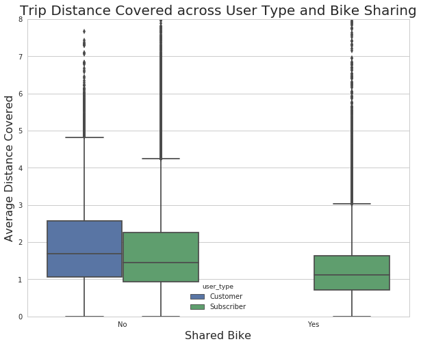

## User Type Vs Gender vs Trip Duration

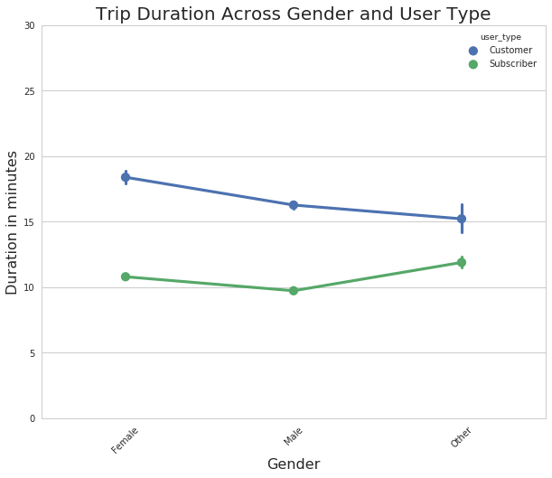

## Conclusion

1. Only subscribers can share their bikes during the trip.
2. Customers averaged more durations during the trip than subscribers.
3. Gender is among the factors that affected trip durations, where females spent more time with the bikes than Males.
4. Riders who didint share their bikes during the trip averaged more distance than those who shared their bikes.
5. The average distance covered for all the trip is about 1.7KM.
6. The Male counterparts were the majority of the riders (75%) with the females 23% and others trailing at 2%.